# Poem Embeddings Explorer

> **Requires:** An OpenAI API key stored as `OPENAI_API_KEY` in your `.Renviron` (run `usethis::edit_r_environ()` to open it). You’ll also need `install.packages(c("openai", "ggrepel"))` if not already installed.

## Configuration

This is the only section you need to edit when switching poems. All downstream chunks read from the objects defined here.

```r
library(tidyverse)
library(openai)

# ── 1. Poem metadata ──────────────────────────────────────────────────────────
poem_title  <- "Digging"
poem_author <- "Seamus Heaney"

# ── 2. Poem text ──────────────────────────────────────────────────────────────
# Paste the full poem as a plain string.
# Separate stanzas with a blank line; the parser does the rest.
poem_raw <- "
Between my finger and my thumb
The squat pen rests; snug as a gun.

Under my window, a clean rasping sound
When the spade sinks into gravelly ground:
My father, digging. I look down

Till his straining rump among the flowerbeds
Bends low, comes up twenty years away
Stooping in rhythm through potato drills
Where he was digging.

The coarse boot nestled on the lug, the shaft
Against the inside knee was levered firmly.
He rooted out tall tops, buried the bright edge deep
To scatter new potatoes that we picked,
Loving their cool hardness in our hands.

By God, the old man could handle a spade.
Just like his old man.

My grandfather cut more turf in a day
Than any other man on Toner's bog.
Once I carried him milk in a bottle
Corked sloppily with paper. He straightened up
To drink it, then fell to right away
Nicking and slicing neatly, heaving sods
Over his shoulder, going down and down
For the good turf. Digging.

The cold smell of potato mould, the squelch and slap
Of soggy peat, the curt cuts of an edge
Through living roots awaken in my head.
But I've no spade to follow men like them.

Between my finger and my thumb
The squat pen rests.
I'll dig with it.
"

# ── 3. Stanza arc reference points ────────────────────────────────────────────
# Which stanzas to compare all others against in the arc plot?
# Use 1-based integer indices. NA resolves to the last stanza.
arc_refs <- c(1L, NA)

# ── 4. Concept probes ─────────────────────────────────────────────────────────
# Named character vector: the name is the display label, the value is the
# phrase sent to the embedding model. Specific phrases work better than
# single words — give the model enough context to anchor the concept.
concept_probes <- c(
  "physical labour and toil" = "physical labour and toil",
  "memory and the past"      = "memory and the past",
  "writing and the pen"      = "writing and the pen",
  "nature and the earth"     = "nature and the earth",
  "family and ancestry"      = "family and ancestry"
)

# ── 5. Topic keywords (whole-poem scoring) ────────────────────────────────────
# A plain character vector of keywords or short phrases. These are used to
# produce a single topic-score vector for the whole poem — useful for
# comparing poems against each other later.
# Single concrete words work fine; abstract concepts benefit from a short phrase.
topic_keywords <- c("memory", "labor", "father", "legacy")
```

## Parse

```r
# Split on blank lines → stanzas; split stanzas on newlines → lines
stanza_texts <- str_split(str_trim(poem_raw), "\n\\s*\n")[[1]] |>
  str_trim() |>
  keep(\(x) nchar(x) > 0)

poem_stanzas <- tibble(
  stanza_num = seq_along(stanza_texts),
  # Single-string version for embedding (newlines → spaces)
  text       = str_replace_all(stanza_texts, "\\s*\n\\s*", " "),
  # Short label: stanza number + first few words
  label      = paste0("S", stanza_num, ": ",
                      str_trunc(str_extract(stanza_texts, "^[^\n]+"), 22))
)

poem_lines <- map(seq_along(stanza_texts), \(i) {
  lines <- str_split(stanza_texts[i], "\n")[[1]] |>
    str_trim() |>
    keep(\(x) nchar(x) > 0)
  tibble(stanza = i, text = lines)
}) |>
  list_rbind() |>
  mutate(line_num = row_number())

# Resolve NA in arc_refs to last stanza index
arc_refs <- ifelse(is.na(arc_refs), nrow(poem_stanzas), arc_refs)

cat(glue::glue(
  '"{poem_title}" by {poem_author}\n',
  '{nrow(poem_lines)} lines across {nrow(poem_stanzas)} stanzas'
))
```

```
"Digging" by Seamus Heaney
31 lines across 8 stanzas
```

## The Poem

### Digging

*Seamus Heaney*

Between my finger and my thumb  
The squat pen rests; snug as a gun.

Under my window, a clean rasping sound  
When the spade sinks into gravelly ground:  
My father, digging. I look down

Till his straining rump among the flowerbeds  
Bends low, comes up twenty years away  
Stooping in rhythm through potato drills  
Where he was digging.

The coarse boot nestled on the lug, the shaft  
Against the inside knee was levered firmly.  
He rooted out tall tops, buried the bright edge deep  
To scatter new potatoes that we picked,  
Loving their cool hardness in our hands.

By God, the old man could handle a spade.  
Just like his old man.

My grandfather cut more turf in a day  
Than any other man on Toner’s bog.  
Once I carried him milk in a bottle  
Corked sloppily with paper. He straightened up  
To drink it, then fell to right away  
Nicking and slicing neatly, heaving sods  
Over his shoulder, going down and down  
For the good turf. Digging.

The cold smell of potato mould, the squelch and slap  
Of soggy peat, the curt cuts of an edge  
Through living roots awaken in my head.  
But I’ve no spade to follow men like them.

Between my finger and my thumb  
The squat pen rests.  
I’ll dig with it.

## Embeddings

```r
embed_texts <- function(texts, model = "text-embedding-3-small") {
  result <- openai::create_embedding(model = model, input = texts)
  do.call(rbind, result$data$embedding)
}

line_emb   <- embed_texts(poem_lines$text)
stanza_emb <- embed_texts(poem_stanzas$text)
```

## Cosine Similarity

Cosine similarity measures the angle between two embedding vectors: 1 means identical direction (very similar meaning), 0 means orthogonal (unrelated).

```r
cosine_matrix <- function(mat) {
  norms    <- sqrt(rowSums(mat^2))
  mat_norm <- mat / norms
  round(mat_norm %*% t(mat_norm), 3)
}

line_sim   <- cosine_matrix(line_emb)
stanza_sim <- cosine_matrix(stanza_emb)
```

### Line-level heatmap

Each cell shows how semantically similar two lines are. The diagonal is always 1 (a line compared to itself).

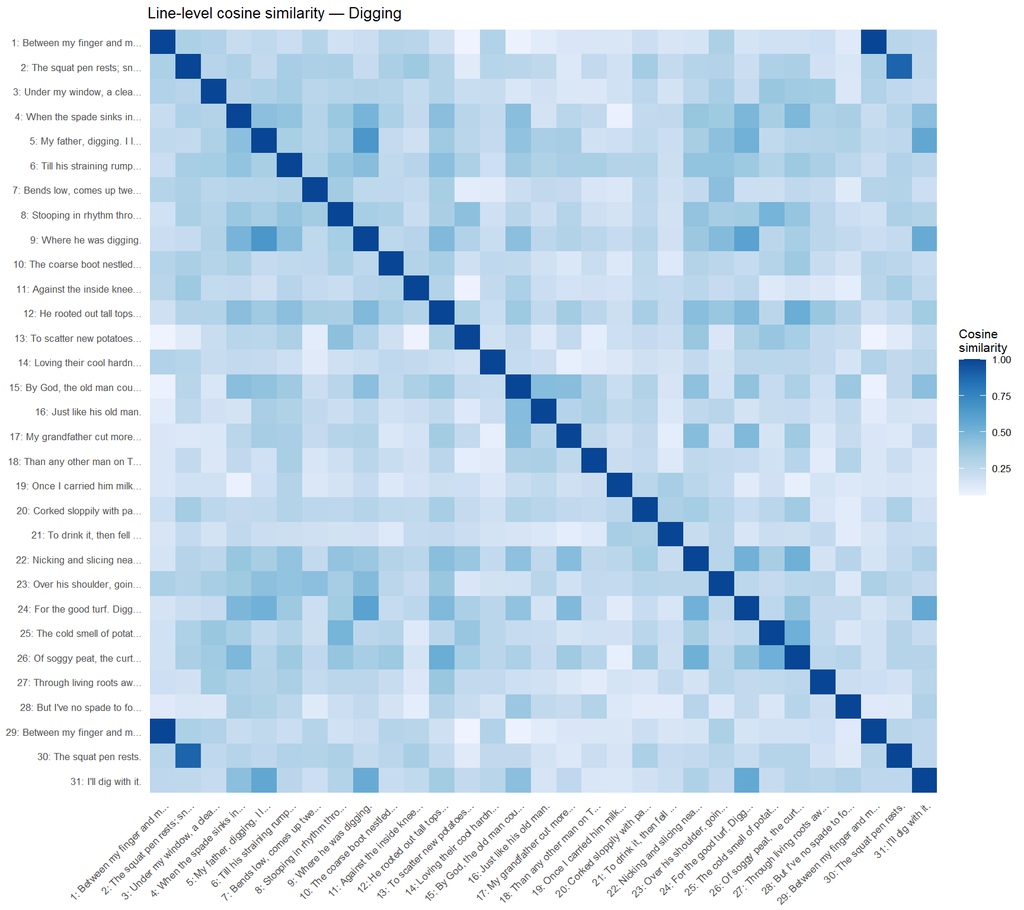

```r
short_label <- paste0(poem_lines$line_num, ": ",
                      str_trunc(poem_lines$text, 26))

expand.grid(line_a = seq_len(nrow(line_sim)),
            line_b = seq_len(nrow(line_sim))) |>
  mutate(
    similarity = line_sim[cbind(line_a, line_b)],
    label_a    = factor(short_label[line_a], levels = short_label),
    label_b    = factor(short_label[line_b], levels = rev(short_label))
  ) |>
  ggplot(aes(x = label_a, y = label_b, fill = similarity)) +
  geom_tile() +
  scale_fill_distiller(palette = "Blues", direction = 1,
                       name = "Cosine\nsimilarity") +
  theme_minimal(base_size = 8) +
  theme(
    axis.text.x = element_text(angle = 45, hjust = 1),
    axis.title  = element_blank(),
    panel.grid  = element_blank()
  ) +
  labs(title = glue::glue("Line-level cosine similarity — {poem_title}"))
```

### Stanza-level heatmap

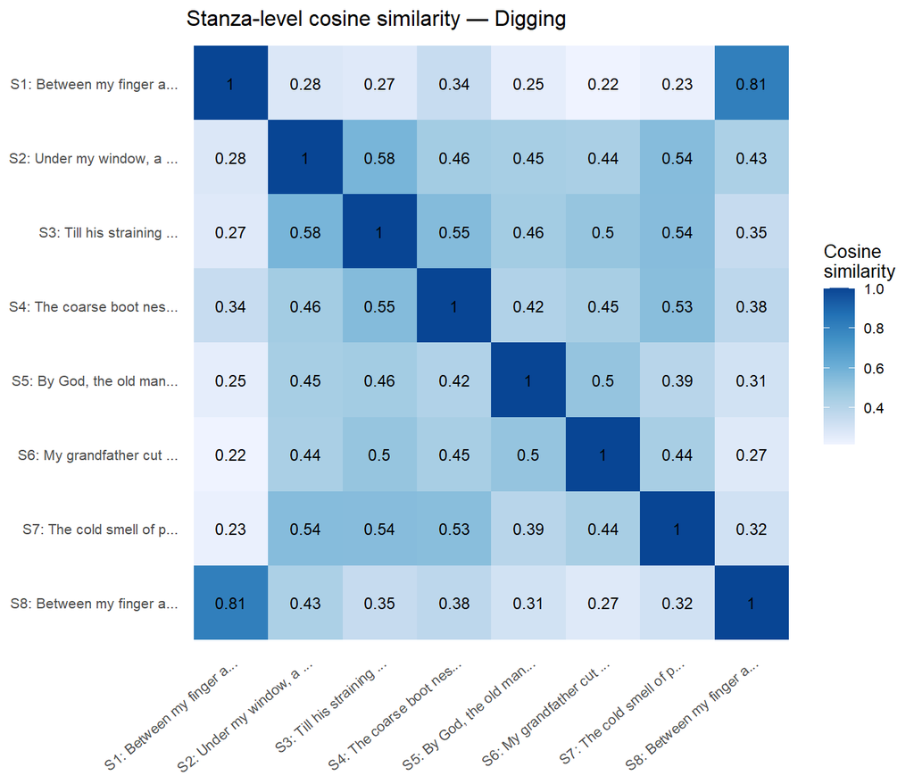

```r
expand.grid(stanza_a = seq_len(nrow(stanza_sim)),
            stanza_b = seq_len(nrow(stanza_sim))) |>
  mutate(
    similarity = stanza_sim[cbind(stanza_a, stanza_b)],
    label_a    = factor(poem_stanzas$label[stanza_a],
                        levels = poem_stanzas$label),
    label_b    = factor(poem_stanzas$label[stanza_b],
                        levels = rev(poem_stanzas$label))
  ) |>
  ggplot(aes(x = label_a, y = label_b, fill = similarity)) +
  geom_tile() +
  geom_text(aes(label = round(similarity, 2)), size = 3.2) +
  scale_fill_distiller(palette = "Blues", direction = 1,
                       name = "Cosine\nsimilarity") +
  theme_minimal(base_size = 10) +
  theme(
    axis.text.x = element_text(angle = 40, hjust = 1),
    axis.title  = element_blank(),
    panel.grid  = element_blank()
  ) +
  labs(title = glue::glue("Stanza-level cosine similarity — {poem_title}"))
```

## PCA: Lines in Embedding Space

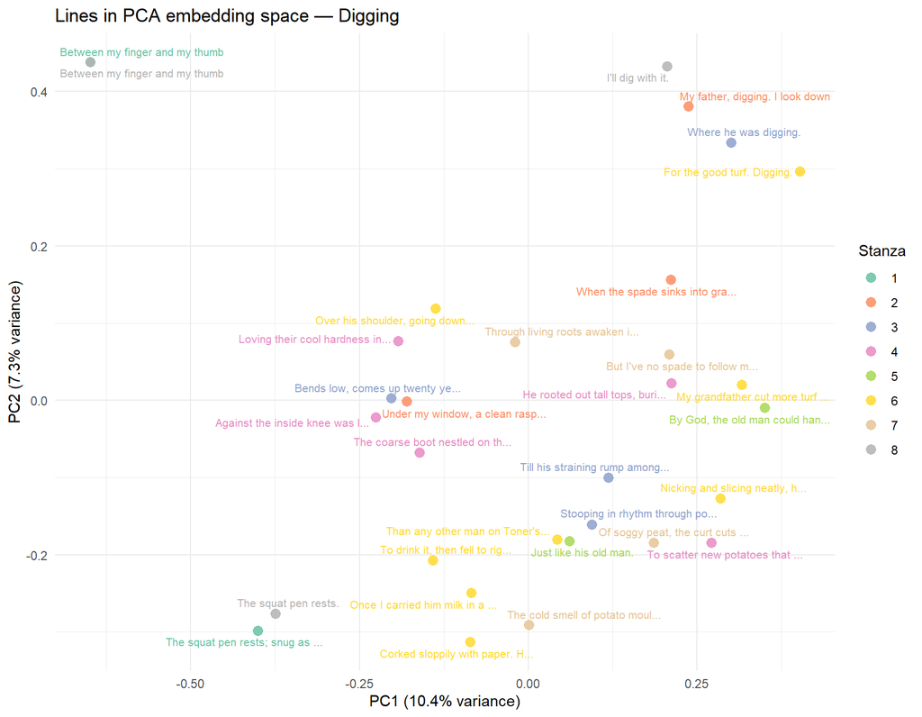

```r
pca_fit <- prcomp(line_emb, scale. = FALSE)
var_exp <- summary(pca_fit)$importance["Proportion of Variance", 1:2] * 100

as_tibble(pca_fit$x[, 1:2]) |>
  bind_cols(poem_lines) |>
  mutate(short_text = str_trunc(text, 32)) |>
  ggplot(aes(x = PC1, y = PC2, color = factor(stanza), label = short_text)) +
  geom_point(size = 3, alpha = 0.85) +
  ggrepel::geom_text_repel(size = 2.8, max.overlaps = 20,
                            show.legend = FALSE) +
  scale_color_brewer(palette = "Set2", name = "Stanza") +
  labs(
    title = glue::glue("Lines in PCA embedding space — {poem_title}"),
    x     = sprintf("PC1 (%.1f%% variance)", var_exp[1]),
    y     = sprintf("PC2 (%.1f%% variance)", var_exp[2])
  ) +
  theme_minimal(base_size = 11)
```

## Most & Least Similar Line Pairs

```r
line_sim_pairs <- expand.grid(
    line_a = seq_len(nrow(line_sim)),
    line_b = seq_len(nrow(line_sim))
  ) |>
  filter(line_a < line_b) |>
  mutate(
    similarity = line_sim[cbind(line_a, line_b)],
    text_a     = poem_lines$text[line_a],
    text_b     = poem_lines$text[line_b]
  )

cat("--- Most similar pairs ---\n")
```

```
--- Most similar pairs ---
```

```r
line_sim_pairs |>
  slice_max(similarity, n = 8) |>
  select(similarity, text_a, text_b) |>
  print()
```

```
  similarity                                               text_a
1      1.000                       Between my finger and my thumb
2      0.890                  The squat pen rests; snug as a gun.
3      0.658                      My father, digging. I look down
4      0.600                                Where he was digging.
5      0.571                      My father, digging. I look down
6      0.561                          For the good turf. Digging.
7      0.549                                Where he was digging.
8      0.537 He rooted out tall tops, buried the bright edge deep
                                   text_b
1          Between my finger and my thumb
2                    The squat pen rests.
3                   Where he was digging.
4             For the good turf. Digging.
5                       I'll dig with it.
6                       I'll dig with it.
7                       I'll dig with it.
8 Of soggy peat, the curt cuts of an edge
```

```r
cat("\n--- Least similar pairs ---\n")
```

```
--- Least similar pairs ---
```

```r
line_sim_pairs |>
  slice_min(similarity, n = 8) |>
  select(similarity, text_a, text_b) |>
  print()
```

```
  similarity                                      text_a
1      0.063              Between my finger and my thumb
2      0.063     To scatter new potatoes that we picked,
3      0.068 Against the inside knee was levered firmly.
4      0.079              Between my finger and my thumb
5      0.079   By God, the old man could handle a spade.
6      0.084  When the spade sinks into gravelly ground:
7      0.093         Once I carried him milk in a bottle
8      0.095    Loving their cool hardness in our hands.
                                     text_b
1   To scatter new potatoes that we picked,
2            Between my finger and my thumb
3   To scatter new potatoes that we picked,
4 By God, the old man could handle a spade.
5            Between my finger and my thumb
6       Once I carried him milk in a bottle
7   Of soggy peat, the curt cuts of an edge
8     My grandfather cut more turf in a day
```

## Stanza Arc

How does each stanza relate semantically to the reference stanzas set in `arc_refs`? This is most revealing when the reference stanzas represent structural anchors — an opening image, a volta, a closing resolution.

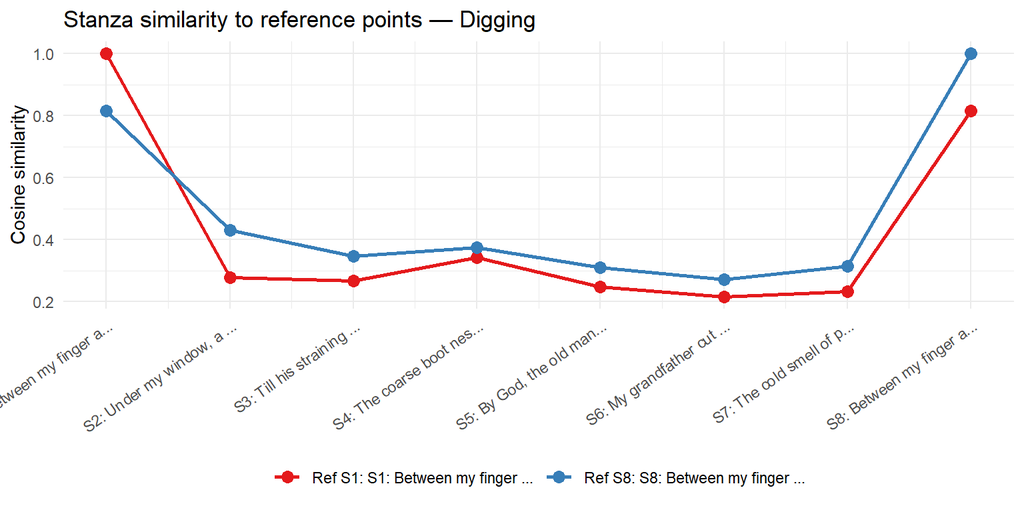

```r
map(arc_refs, \(ref) {
  tibble(
    stanza_num = poem_stanzas$stanza_num,
    label      = poem_stanzas$label,
    reference  = paste0("Ref S", ref, ": ",
                        str_trunc(poem_stanzas$label[ref], 25)),
    similarity = stanza_sim[, ref]
  )
}) |>
  list_rbind() |>
  ggplot(aes(x = stanza_num, y = similarity,
             color = reference, group = reference)) +
  geom_line(linewidth = 1) +
  geom_point(size = 3) +
  scale_x_continuous(breaks = poem_stanzas$stanza_num,
                     labels = poem_stanzas$label,
                     guide  = guide_axis(angle = 35)) +
  scale_color_brewer(palette = "Set1", name = NULL) +
  labs(
    title = glue::glue("Stanza similarity to reference points — {poem_title}"),
    x     = NULL,
    y     = "Cosine similarity"
  ) +
  theme_minimal(base_size = 11) +
  theme(legend.position = "bottom")
```

## Concept Probing

Individual embedding dimensions are not human-interpretable — meaning is distributed across all dimensions simultaneously. But we can define semantic directions by embedding a concept phrase and projecting each line onto that direction. Edit `concept_probes` in the **Configuration** section at the top to change or add concepts.

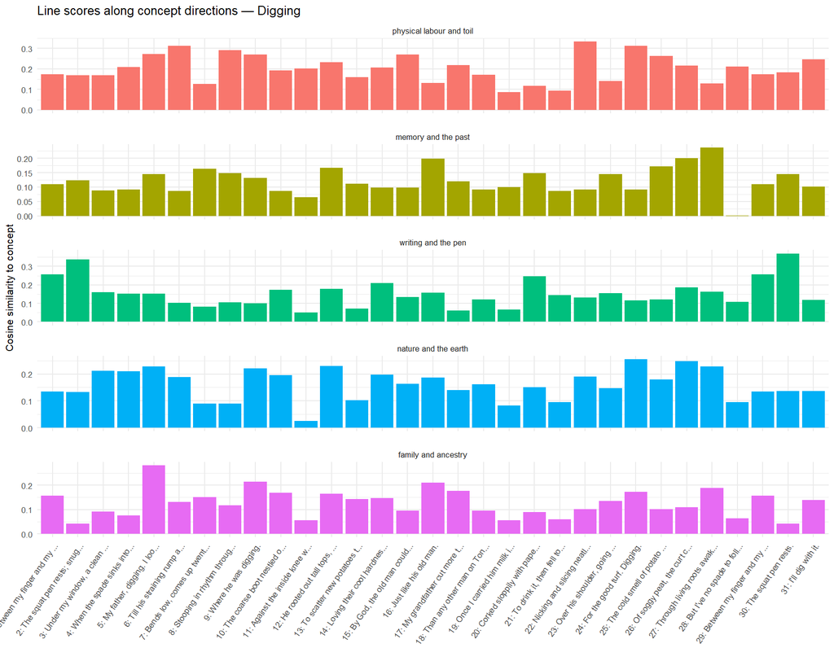

```r
concept_result <- openai::create_embedding(
  model = "text-embedding-3-small",
  input = unname(concept_probes)
)
concept_mat <- do.call(rbind, concept_result$data$embedding)

l2_norm <- function(mat) mat / sqrt(rowSums(mat^2))

scores <- l2_norm(line_emb) %*% t(l2_norm(concept_mat))
colnames(scores) <- names(concept_probes)

as_tibble(scores) |>
  bind_cols(poem_lines |> select(line_num, text)) |>
  pivot_longer(
    cols      = all_of(names(concept_probes)),
    names_to  = "concept",
    values_to = "score"
  ) |>
  mutate(
    concept    = factor(concept, levels = names(concept_probes)),
    short_text = fct_inorder(paste0(line_num, ": ", str_trunc(text, 28)))
  ) |>
  ggplot(aes(x = short_text, y = score, fill = concept)) +
  geom_col() +
  facet_wrap(~ concept, ncol = 1, scales = "free_y") +
  theme_minimal(base_size = 8) +
  theme(
    axis.text.x     = element_text(angle = 55, hjust = 1),
    legend.position = "none",
    panel.spacing   = unit(0.8, "lines")
  ) +
  labs(
    title = glue::glue("Line scores along concept directions — {poem_title}"),
    x     = NULL,
    y     = "Cosine similarity to concept"
  )
```